# Power analysis

```r
library(ggplot2)
```

# Simulating from the hypothesised data-generating process for power analysis

The experiment can be logically divided into three separate experiments. The first experiment (Experiment 1) is based on estimating the effect of nitrogen on the strength of the plant-soil feedback for natives only. The second experiment (Experiment 2) estimates the effect of nitrogen on the strength of the plant-soil feedback for invasives only. And, finally, the third experiment (Experiment 3) examines whether the competitive effect of invasives on natives changes with nitrogen and microbes.

To develop the simulation, we focused on the first experiment. This served as the base for the rest of the simulations that we used to conduct the power analysis. Specifically, the generative model is based on modelling the biomass of native plants (L) after 8-weeks of growth as a function of experimental nitrogen-level (N) and the presence or absence of soil microbes (M). We can represent this with a very simple Directed Acyclic Graph (DAG):

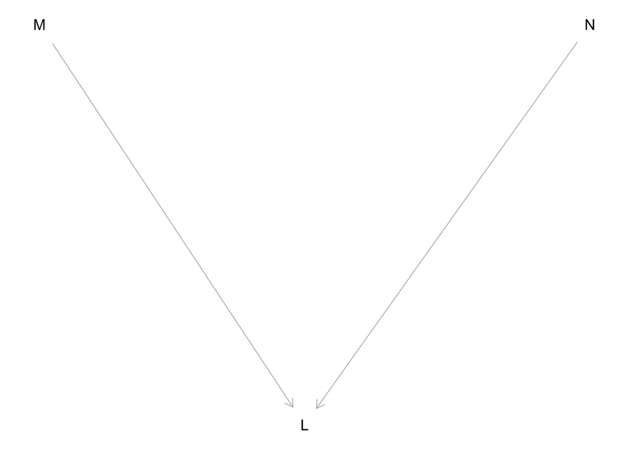

```r
dag1 <- dagitty::dagitty(x = 'dag {
bb="0,0,1,1"
L [pos="0.28,0.29"]
M [pos="0.215,0.200"]
N [pos="0.35,0.200"]
M -> L
N -> L
}'
)
plot(dag1)
```

This DAG can be modelled this as a simple linear model. However, we are interested in the *proportional* changes in native plant biomass. Therefore, we will fit the model on the log-scale. This implies the following generative model on the natural scale:

$$L_{i} = e^{\alpha + \beta_1\text{N}_{i} + \beta_2\text{M}_{i} + \beta_3\text{N}_{i}\text{M}_{i} + \epsilon_{i}} \\
\epsilon_{i} \sim Normal(0, \sigma_{residual})$$
We simulate this model in the following way. First, we simulate the data based on the experimental design. The experimental design crosses four levels of nitrogen (4, 8, 16 and 32 mg) (N) with the presence or absence of conditioned microbes (M). For this initial simulation, we set the number of replicates (n_rep) to 100 per treatment combination as we are interested in making sure the model works (this will be reduced for the power analysis of course).

```r
# set the number of replicates
n_rep <- 100

# nitrogen-levels
N_lev <- log(c(4, 8, 16, 32))

# soil microbe presence-absence
M_lev <- c(0, 1)

# simulate the nitrogen values
N <- rep(rep(N_lev,  each = n_rep), length(M_lev))

# transform so that the intercept represents the lowest level of nitrogen
N <- (N - min(N))

# simulate the microbe presence-absence
M <- rep(M_lev, each = length(N_lev)*n_rep)
```

Next, we set-up some model parameters. The $\beta$ parameters in the model represents the proportional change in plant biomass on the natural scale. These parameters therefore need to be carefully chosen so that they make sense on the log-scale. For the purposes of this initial simulation, this is not that important but we provide the transformation so that the interpretation the natural scale is also clear:

```r
# set the model parameters

# residual standard deviation
sigma_residual <- 0.10

# alpha - mean plant biomass without microbes (log)
alpha <- 1.5
print(paste0("alpha: ", round(exp(alpha), 2), " dry biomass (mg) without microbes when N is zero"))
```

```
[1] "alpha: 4.48 dry biomass (mg) without microbes when N is zero"
```

```r
# beta1 - expected change in mean plant biomass without microbes (log)
beta1 <- 0.2
print(paste0("beta1: ", round(exp(beta1) - 1, 2)*100, " % change in plant biomass for a one unit increase in N"))
```

```
[1] "beta1: 22 % change in plant biomass for a one unit increase in N"
```

```r
# beta2 - expected change in mean plant biomass with and without microbes when N is zero (log)
beta2 <- -0.12
print(paste0("beta2: ", round(exp(beta2) - 1, 2)*100, " % change in plant biomass with microbes when N is 0"))
```

```
[1] "beta2: -11 % change in plant biomass with microbes when N is 0"
```

```r
# beta3 - additional change in the effect of N on mean plant biomass with microbes compareed to without microbes (log)
beta3 <- 0
print(paste0("beta3: ", round(exp(beta3) - 1, 2)*100, " % change in plant biomass for a simultaneous increase in N by one unit and with microbes beyond their individual effects"))
```

```
[1] "beta3: 0 % change in plant biomass for a simultaneous increase in N by one unit and with microbes beyond their individual effects"
```

Using this generative model, we can simulate the observed native plant biomass (L) on the natural-scale as follows:

```r
# simulate the observed plant biomass on the natural scale
L <- (exp(alpha + (beta1 * N) + (beta2 * M) + (beta3 * N * M) + rnorm(n = length(N), 0, sigma_residual)))
```

Using these simulated data, we fit a linear model on the log scale and therefore we transform the model as follows:

$$log(L_{i}) = \alpha + \beta_1\text{N}_{i} + \beta_2\text{M}_{i} + \beta_3\text{N}_{i}\text{M}_{i} + \epsilon_{i} \\
\epsilon_{i} \sim Normal(0, \sigma_{residual})$$
After fitting the model and inspecting the parameters, we can see that we can recover the simulated parameters very closely (note that the intercept needs to be exponentiated).

```r
# fit the linear model
lm1 <- lm(log(L) ~ N + M + N:M)

# extract the summary
lm1_sum <- summary(lm1)

# print the summary
lm1_sum$sigma
```

```
[1] 0.09719171
```

```r
lm1_sum
```

```
Call:
lm(formula = log(L) ~ N + M + N:M)

Residuals:
     Min       1Q   Median       3Q      Max
-0.34017 -0.06952  0.00224  0.06234  0.35903

Coefficients:
             Estimate Std. Error t value Pr(>|t|)
(Intercept)  1.505026   0.008132 185.083   <2e-16 ***
N            0.197988   0.006271  31.573   <2e-16 ***
M           -0.128062   0.011500 -11.136   <2e-16 ***
N:M          0.005044   0.008868   0.569     0.57
---
Signif. codes:  0 '***' 0.001 '**' 0.01 '*' 0.05 '.' 0.1 ' ' 1

Residual standard error: 0.09719 on 796 degrees of freedom
Multiple R-squared:  0.7481,    Adjusted R-squared:  0.7472
F-statistic: 788.2 on 3 and 796 DF,  p-value: < 2.2e-16
```

Wrap the input parameters and the estimated parameters into a table for comparison. As we can see, our model can succesfully reproduce the parameters that we input.

```r
# make a table of the observed and estimated parameter values
dplyr::tibble(parameter = c("alpha", "beta1", "beta2", "beta3"),
              input = c(alpha, beta1, beta2, beta3),
              estimate = broom::tidy(lm1_sum)[[2]])
```

```
# A tibble: 4 × 3
  parameter input estimate
  <chr>     <dbl>    <dbl>
1 alpha      1.5   1.51
2 beta1      0.2   0.198
3 beta2     -0.12 -0.128
4 beta3      0     0.00504
```

To interpret these parameters on the natural scale, we need to transform them:

```r
# extract the model parameters
lm1_pars <- broom::tidy(lm1_sum)

# wrap into a data.frame
dplyr::tibble(parameter = c("alpha", "beta1", "beta2", "beta3"),
              estimate_natural = c(exp(lm1_pars[["estimate"]][1]),
                                   (exp(lm1_pars[["estimate"]][2]) - 1)*100,
                                   (exp(lm1_pars[["estimate"]][3]) - 1)*100,
                                   (exp(lm1_pars[["estimate"]][4]) - 1)*100),
              interpretation = c("dry biomass (mg) without microbes when N is zero",
                                 "% change in plant biomass for a one unit increase in N without microbes",
                                 "% change in plant biomass with microbes when N is 0",
                                 "% change in plant biomass for a simultaneous increase in one unit N and microbes")
              )
```

```
# A tibble: 4 × 3
  parameter estimate_natural interpretation
  <chr>                <dbl> <chr>
1 alpha                4.50  dry biomass (mg) without microbes when N is zero
2 beta1               21.9   % change in plant biomass for a one unit increase …
3 beta2              -12.0   % change in plant biomass with microbes when N is 0
4 beta3                0.506 % change in plant biomass for a simultaneous incre…
```

Let’s visualise these data and see what we get. Based on the simulations, N positively affects L, M negatively affects L and there is no interaction between N and M i.e. the effect of M on L does not change with N (or *vice versa*). Below, we have plotted the data on the log-scale on the left and on the natural-scale on the right. As we simulated, there is no interaction between N and M on the log-scale (i.e. the lines are parallel). This makes sense because we specified $\beta_3$ as zero in the simulation. However, on the natural-scale, the lines are not perfectly parallel (even though we set the interaction be zero, there is still a very small but non-significant interaction effect) which suggests that there is an interaction on the natural scale. What is going on here? Because we have used the log-scale, the proportional change in plant biomass L with and without microbes is equal across N-levels (i.e. parallel lines on the log-scale). However, in absolute terms, the difference in plant biomass (L) with and without microbes (M) is bigger with higher N.

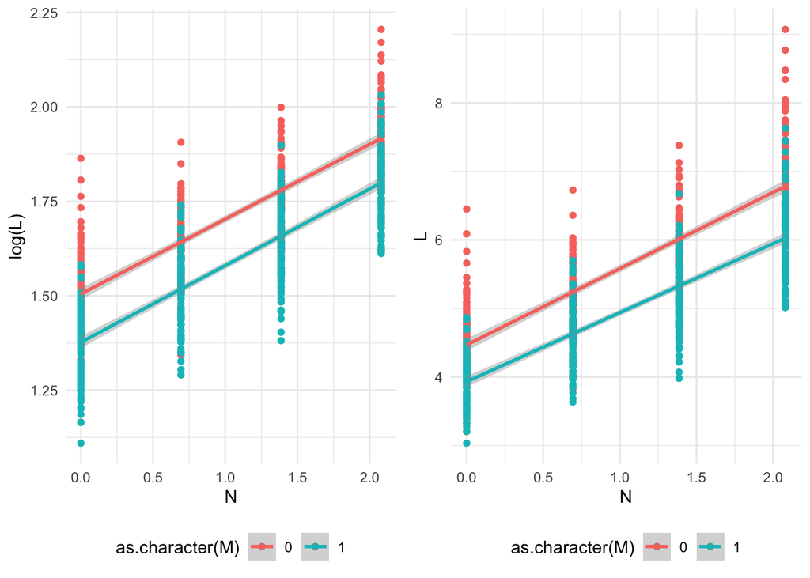

```r
# plot the data on the log-scale
p1 <-
  ggplot(mapping = aes(x = N, y = log(L), colour = as.character(M))) +
  geom_point() +
  geom_smooth(method = "lm") +
  theme_minimal() +
  theme(legend.position = "bottom")

# plot the data on the natural scale
p2 <-
  ggplot(mapping = aes(x = N, y = L, colour = as.character(M))) +
  geom_point() +
  geom_smooth(method = "lm") +
  theme_minimal() +
  theme(legend.position = "bottom")

cowplot::plot_grid(p1, p2, nrow = 1)
```

Indeed, if we calculate plant-soil feedback using the following metric, we can confirm that the strength of the plant-soil feedback (PSF) in proportion terms does not change with N where $\overline{L}$ is the average across replicates of plant biomass:

$$PSF_j = \frac{\overline{L}_{microbes} - \overline{L}_{no \ microbes}}{\overline{L}_{no \ microbes}}$$

If we plot this metric of plant-soil feedback with N, we will see that there is no change in the strength of the plant-soil feedback with N in proportional terms:

```r
# calculate plant-soil feedback metric
e1_dat <- dplyr::tibble(N = N,
                        M = M,
                        L = L)

# check the data
e1_dat_wide <-
  e1_dat |>
  dplyr::group_by(N, M) |>
  dplyr::summarise(L_m = mean(L)) |>
  tidyr::pivot_wider(id_cols = "N",
                     names_from = "M",
                     values_from = "L_m")
```

[output not shown]

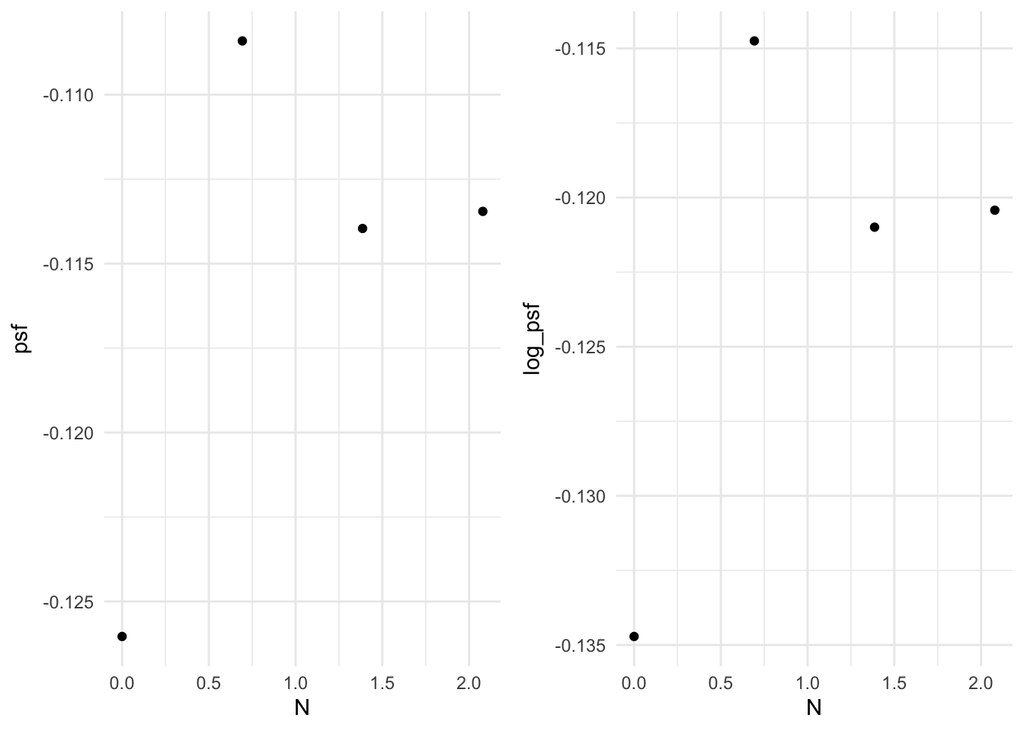

```r
names(e1_dat_wide) <- c("N", "M_abs", "M_pres")

# calculate plant-soil feedback
e1_dat_wide$psf <- with(e1_dat_wide, (M_pres-M_abs)/M_abs)
e1_dat_wide$log_psf <- with(e1_dat_wide, log(M_pres/M_abs))

# plot the data with Elias' metric
p1 <-
  ggplot(data = e1_dat_wide,
       mapping = aes(x = N, y = psf)) +
  geom_point() +
  theme_minimal()

# plot the data with the log response-ratio
p2 <-
  ggplot(data = e1_dat_wide,
       mapping = aes(x = N, y = log_psf)) +
  geom_point() +
  theme_minimal()

cowplot::plot_grid(p1, p2, nrow = 1)
```

```r
# psf metric on the natural scale
cor.test(e1_dat_wide$N, e1_dat_wide$psf)
```

```
    Pearson's product-moment correlation

data:  e1_dat_wide$N and e1_dat_wide$psf
t = 0.94511, df = 2, p-value = 0.4444
alternative hypothesis: true correlation is not equal to 0
95 percent confidence interval:
 -0.8700944  0.9887279
sample estimates:
      cor
0.5556348
```

This simple simulation confirms that we can use the interaction term (i.e. $\beta_3$) as a way to determine whether the plant-soil feedback changes with nitrogen (N) (see also Bates et al. 2019, Plant Ecology). It is easy to modify the strength of the interaction term in the above-code to see how this leads to positive or negative changes in plant-soil feedback.

We want to use this simulation to estimate the power of detecting a change in plant-soil feedback (i.e. a $\beta_3$ parameter that differs significantly from zero). For this, we start by wrapping this code into a function where the various parameters can easily be changed:

```r
#' @param group Character. Native or Invasive species ("L", "I").
#' @param n_rep Integer. Number of replicates for each nitrogen-microbe combination.
#' @param sigma_residual Numeric. Residual standard deviation for log biomass.
#' @param N_lev Numeric vector. Log-transformed nitrogen levels.
#' @param M_lev Numeric vector. Soil microbe presence-absence (0 for absence, 1 for presence).
#' @param alpha Numeric. Intercept representing the mean biomass without microbes on the natural scale.
#' @param beta1 Numeric. Expected change in mean biomass with increasing nitrogen without microbes.
#' @param beta2 Numeric. Effect of microbes on mean biomass when nitrogen level is zero.
#' @param beta3 Numeric. Additional change in the effect of nitrogen with microbes compared to without microbes.

simulate_species_alone <- function(
  group = "L",
  n_rep = 10,
  sigma_residual = 0.15,
  N_lev = log(c(4, 8, 16, 32)),
  M_lev = c(0, 1),
  alpha = 1.5,
  beta1 = 0.2,
  beta2 = -0.12,
  beta3 = 0
) {
  # simulate nitrogen values
  N <- rep(rep(N_lev, each = n_rep), length(M_lev))

  # transform nitrogen so that intercept represents the lowest level of nitrogen
  N <- (N - min(N))

  # simulate microbe presence-absence
  M <- rep(M_lev, each = length(N_lev) * n_rep)

  # simulate the expected log plant biomass
  mu <- (beta1 * N) + (beta2 * M) + (beta3 * N * M) + rnorm(n = length(N), mean = 0, sd = sigma_residual)

  # transform back from log-scale and apply alpha
  Y <- alpha * exp(mu)

  # return the simulated data as a data frame
  dplyr::tibble("N" = N, "M" = M, group = Y)
}
```

We then wrap this simulation into an additional function that allows us to simulate these data under the null hypothesis (e.g. $\beta_3$ = 0) and under some alternative hypothesis (e.g. $\beta_3$ = -0.10). The other parameters can also be varied so that we can estimate the power of our test given some null and alternative hypothesis conditional on, for example, a residual standard deviation of 0.10 ($\sigma_{residual}$).

```r
#' @param n_sim - number of simulations to run of the experiment
#' @param beta3_h0 - beta3 under the null hypothesis
#' @param beta3_ha - beta3 under the alternative hypothesis
#
species_alone_power <- function(
    n_sim = 10,
    alpha_rej = 0.05,
    group = "L",
    n_rep = 100,
    sigma_residual = 0.15,
    N_lev = log(c(4, 8, 16, 32)),
    M_lev = c(0, 1),
    alpha = 1.5,
    beta1 = 0.2,
    beta2 = -0.12,
    beta3_h0 = 0,
    beta3_ha = -0.05) {

  # initialize vectors to store Type I and Type II errors
  type_I_errors <- vector(length = n_sim)
  type_II_errors <- vector(length = n_sim)

  # simulate under H0 (Null Hypothesis)
  for (i in seq_len(n_sim)) {

    # generate data under H0
    data_h0 <-
      simulate_species_alone(
        group = group,
        n_rep = n_rep,
        sigma_residual = sigma_residual,
        N_lev = N_lev,
        M_lev = M_lev,
        alpha = alpha,
        beta1 = beta1,
        beta2 = beta2,
        beta3 = beta3_h0)

    # rename the data
    names(data_h0) <- c("N", "M", "Y")

    # fit the model under H0
    model_h0 <- lm(log(Y) ~ N + M + N:M, data_h0)

    # extract the relevant p-value
    p_value_h0 <- coef(summary(model_h0))["N:M", "Pr(>|t|)"]

    # collect Type I error
    type_I_errors[i] <- as.numeric(p_value_h0 < alpha_rej)

    }

  # simulate under HA (Alternative Hypothesis)
  for (i in seq_len(n_sim)) {

    # generate data under HA
    data_ha <-
      simulate_species_alone(
        group = group,
        n_rep = n_rep,
        sigma_residual = sigma_residual,
        N_lev = N_lev,
        M_lev = M_lev,
        alpha = alpha,
        beta1 = beta1,
        beta2 = beta2,
        beta3 = beta3_ha)

    # rename the data
    names(data_ha) <- c("N", "M", "Y")

    # fit the model under H0
    model_ha <- lm(log(Y) ~ N + M + N:M, data_ha)

    # extract the relevant p-value
    p_value_ha <- coef(summary(model_ha))["N:M", "Pr(>|t|)"]

    # collect Type I error
    type_II_errors[i] <- as.numeric(p_value_ha >= alpha_rej)

  }

  # calculate metrics
  type_I_error_rate <- sum(type_I_errors, na.rm = TRUE) / length(na.omit(type_I_errors))
  type_II_error_rate <- sum(type_II_errors, na.rm = TRUE) / length(na.omit(type_II_errors))
  power <- 1 - type_II_error_rate

  # return results
  list(
    type_I_error_rate = type_I_error_rate,
    type_II_error_rate = type_II_error_rate,
    power = power
  )

}
```

As a test of this function, we can run a power analysis for a specific set of parameters:

```r
# test the function for running the power analysis
power_test <-
  species_alone_power(n_sim = 100,
                      alpha_rej = 0.05,
                      group = "L",
                      n_rep = 7,
                      sigma_residual = 0.15,
                      N_lev = log(c(4, 8, 16, 32, 64)),
                      M_lev = c(0, 1),
                      alpha = 1.5,
                      beta1 = 0.15,
                      beta2 = -0.29,
                      beta3_h0 = 0,
                      beta3_ha = -0.1)

# print the results
power_test
```

```
$type_I_error_rate
[1] 0.02

$type_II_error_rate
[1] 0.26

$power
[1] 0.74
```

Using these functions, we will conduct a power analysis for experiment 1 and experiment 2 (as they have a similar structure).

## Power analysis:

## Experiment 1:

For the power analysis for experiment 1, we needed to obtain reasonable estimates for four parameters: $\alpha$, $\beta_1$, $\beta_2$ and $\sigma_{residual}$. Based on the experimental design and the way that we have decided to set-up the model, $\alpha$ represents the mean native plant biomass (L) on the log-scale without microbes, for the lowest level of nitrogen (4 mg). Previous work with these native species indicates that 4.5 g is reasonable for the dry-weight of these plants without microbes and at low nitrogen values (e.g. Goossens et al. 2023, *npj biodiversity*). For the effect of nitrogen (N), we used estimates from Minden and Olde Venterinck (2019, *Functional Ecology*) where, for these native species, an increase of between 0 and 15% per log-unit of nitrogen was measured. The effect of plant-soil feedbacks (i.e. microbes, M) was taken from Schitzer et al. (2011, *Ecology*) who measured a reduction of plant biomass of between 10 and 40% due to the presence of microbes. Finally, we estimated $\sigma_{residual}$ based on data from a previous, unpublished experiment on the same species (MSc thesis).

Based on these estimates, we performed the simulations for combinations of these values:

- $\alpha$ = 1.5 g on the log-scale
- $\beta_1$ = 5%, 10% or 15% increase in biomass with N on the natural-scale
- $\beta_2$ = 10%, 25% or 40% decrease in biomass with microbes on the natural-scale for the lowest level of N
- $\sigma_{residual}$ = 0.05, 0.10, 0.15, 0.20, 0.25 on the log-scale

Our hypothesis is based on the $\beta_3$ parameter being negative (i.e. the effect of a simultaneous increase in microbes and N is negative). Therefore, we estimated power based on four hypothesised values:

- $\beta_3$ = 2.5%, 5%, 7.5% or 10% decrease in biomass with a simultaneous increase of N by 1 unit and the presence of microbes on the natural-scale beyond the effects of each alone

```r
# set-up the parameters

# convert percentage to parameter for the log-scale
par_target <- function(target) log(1 + target)

# number of replicates
n_rep <- seq(1, 10, 1)

# alpha - mean plant biomass without microbes on the log-scale
alpha <- 1.5

# beta1 - expected change in mean plant biomass with N without microbes (log-scale)
beta1 <- sapply(c(0.05, 0.10, 0.15), par_target)

# beta2 - expected change in mean plant biomass with and without microbes when N is zero (log-scale)
beta2 <- sapply(c(-0.10, -0.25, -0.40), par_target)

# beta3 - additional change in the effect of N on mean plant biomass with microbes compared to without microbes (log-scale)
beta3 <- sapply(c(-0.10, -0.075, -0.05, -0.025), par_target)

# sigma residual
sigma_residual <- c(0.05, 0.10, 0.15, 0.20, 0.25)

# pull the parameter list into a data.frame
params <- expand.grid(n_rep = n_rep,
                      alpha = alpha, beta1 = beta1,
                      beta2 = beta2, beta3 = beta3,
                      sigma_residual = sigma_residual)

# convert to a tibble
params <- dplyr::as_tibble(params)

# print the first few rows
head(params)
```

```
# A tibble: 6 × 6
  n_rep alpha  beta1  beta2  beta3 sigma_residual
  <dbl> <dbl>  <dbl>  <dbl>  <dbl>          <dbl>
1     1   1.5 0.0488 -0.105 -0.105           0.05
2     2   1.5 0.0488 -0.105 -0.105           0.05
3     3   1.5 0.0488 -0.105 -0.105           0.05
4     4   1.5 0.0488 -0.105 -0.105           0.05
5     5   1.5 0.0488 -0.105 -0.105           0.05
6     6   1.5 0.0488 -0.105 -0.105           0.05
```

```r
# loop over each of these parameter combinations
power_list <- vector("list", length = nrow(params))
for (i in seq_along(power_list)) {

  # get the input parameters
  input_pars <- params[i, ]

  # run the simulation
  power_sim_data <-
    species_alone_power(n_sim = 1000,
                        alpha_rej = 0.025,
                        group = "L",
                        n_rep = input_pars$n_rep,
                        sigma_residual = input_pars$sigma_residual,
                        N_lev = log(c(4, 8, 16, 32)),
                        M_lev = c(0, 1),
                        alpha = input_pars$alpha,
                        beta1 = input_pars$beta1,
                        beta2 = input_pars$beta2,
                        beta3_h0 = 0,
                        beta3_ha = input_pars$beta3)

  # add the type I error, type II error and power to a list
  power_list[[i]] <-
    dplyr::tibble(run = i,
                  type_1_error = power_sim_data$type_I_error_rate,
                  type_2_error = power_sim_data$type_II_error_rate,
                  power = power_sim_data$power)

}

# bind into a data.frame
power_data <- dplyr::bind_rows(power_list)
head(power_data)
```

```
# A tibble: 6 × 4
    run type_1_error type_2_error power
  <int>        <dbl>        <dbl> <dbl>
1     1        0.035        0.752 0.248
2     2        0.02         0.245 0.755
3     3        0.013        0.065 0.935
4     4        0.023        0.012 0.988
5     5        0.019        0.006 0.994
6     6        0.03         0     1
```

```r
# bind to the parameter data
power_e1 <- dplyr::bind_cols(params, power_data)

# print the first few rows
head(power_e1)
```

```
# A tibble: 6 × 10
  n_rep alpha  beta1  beta2  beta3 sigma_residual   run type_1_error
  <dbl> <dbl>  <dbl>  <dbl>  <dbl>          <dbl> <int>        <dbl>
1     1   1.5 0.0488 -0.105 -0.105           0.05     1        0.035
2     2   1.5 0.0488 -0.105 -0.105           0.05     2        0.02
3     3   1.5 0.0488 -0.105 -0.105           0.05     3        0.013
4     4   1.5 0.0488 -0.105 -0.105           0.05     4        0.023
5     5   1.5 0.0488 -0.105 -0.105           0.05     5        0.019
6     6   1.5 0.0488 -0.105 -0.105           0.05     6        0.03
# ℹ 2 more variables: type_2_error <dbl>, power <dbl>
```

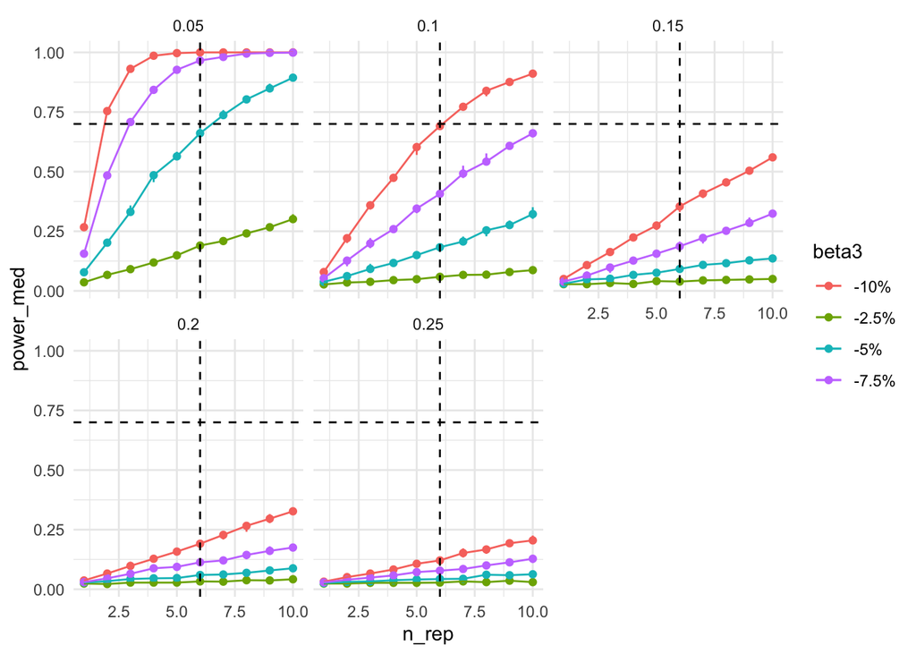

```r
# summarise the data for plotting
power_e1$beta3 <- paste0((exp(power_e1$beta3) - 1)*100, "%")

# summarise the data
power_e1_sum <-
  power_e1 |>
  dplyr::mutate(beta3 = as.character(beta3)) |>
  dplyr::group_by(sigma_residual, beta3, n_rep) |>
  dplyr::summarise(power_med = median(power),
                   quantile_low = quantile(power, 0.10),
                   quantile_high = quantile(power, 0.90))
# plot the data
ggplot(data = power_e1_sum,
       mapping = aes(x = n_rep, y = power_med, colour = beta3)) +
  geom_errorbar(mapping = aes(x = n_rep,
                              ymin = quantile_low, ymax = quantile_high,
                              colour = beta3),
                width = 0) +
  geom_point() +
  geom_line() +
  geom_vline(xintercept = 6, linetype = "dashed") +
  geom_hline(yintercept = 0.70, linetype = "dashed") +
  facet_wrap(~sigma_residual) +
  theme_minimal()
```

## Experiment 2:

The causal structure of experiment 2 is very similar to that of experiment 1. Specifically, the biomass of invasive plants (I) after 8-weeks of growh as a function of experimental nitrogen-level (N) and the presence or absence of soil microbes (M).

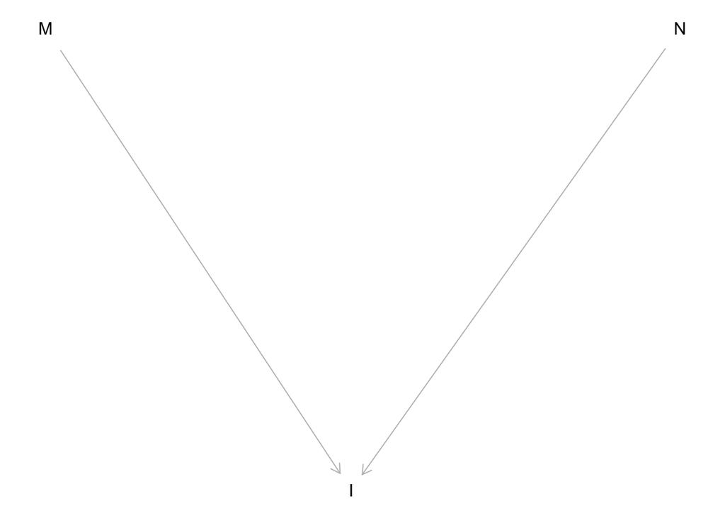

```r
dag2 <- dagitty::dagitty(x = 'dag {
bb="0,0,1,1"
I [pos="0.28,0.29"]
M [pos="0.215,0.200"]
N [pos="0.35,0.200"]
M -> I
N -> I
}'
)
plot(dag2)
```

For the power analysis for experiment 1, we needed to obtain reasonable estimates for four parameters: ($\alpha$), ($\beta_1$), ($\beta_2$), and ($\sigma_\text{residual}$). Based on the experimental design and the way we have decided to set up the model, ($\alpha$) represents the mean biomass (L) of invasive species on the natural-scale without microbes, for the lowest level of nitrogen (4 mg). Previous work with *Solidago gigantea* indicates that 4.5 g is reasonable for the dry weight of these plants without microbes at low nitrogen levels (e.g., Kyle Coppens, MSc thesis: 2023). For the effect of nitrogen (N), we used estimates from Wan et al. (2019, *Journal of Plant Ecology*), where, for *Solidago canadensis*, an increase of between 50% and 300% per log-unit of nitrogen was measured. The effect of plant-soil feedbacks (i.e., microbes, M) was taken from the MSc thesis by Kyle Coppens (2023), which reported a reduction of plant biomass of between 5% and 25% due to the presence of microbes. Finally, we estimated ($\sigma_\text{residual}$) based on data from a previous, unpublished experiment on the same species (MSc thesis).

Our hypothesis is based on the $\beta_3$ parameter being negative (i.e. that plant-soil feedback becomes stronger with N). Therefore, we estimated power based on four hypothesized values:

- $\beta_3$ = 2.5%, 5%, 7.5% or 10% decrease in biomass with a simultaneous increase of N by 1 unit and the presence of microbes on the natural scale beyond the effects of each alone.

```r
# set-up the parameters

# convert percentage to parameter for the log-scale
par_target <- function(target) log(1 + target)

# number of replicates
n_rep <- seq(1, 10, 1)

# alpha - mean plant biomass without microbes on the log-scale
alpha <- 1.5

# beta1 - expected change in mean plant biomass with N without microbes on the log-scale
beta1 <- sapply(c(0.5, 1.5, 3), par_target)

# beta2 - expected change in mean plant biomass with and without microbes when N is minimum
beta2 <- sapply(c(-0.05, -0.15, -0.25), par_target)

# beta3 - additional change in the effect of N on mean plant biomass with microbes compared to without microbes
beta3 <- sapply(c(-0.10, -0.075, -0.05, -0.025), par_target)

# sigma residual
sigma_residual <- c(0.05, 0.10, 0.25, 0.3)

# pull the parameter list into a data.frame
params <- expand.grid(n_rep = n_rep,
                      alpha = alpha, beta1 = beta1,
                      beta2 = beta2, beta3 = beta3,
                      sigma_residual = sigma_residual)

# convert to a tibble
params <- dplyr::as_tibble(params)

# print the first few rows
head(params)
```

```
# A tibble: 6 × 6
  n_rep alpha beta1   beta2  beta3 sigma_residual
  <dbl> <dbl> <dbl>   <dbl>  <dbl>          <dbl>
1     1   1.5 0.405 -0.0513 -0.105           0.05
2     2   1.5 0.405 -0.0513 -0.105           0.05
3     3   1.5 0.405 -0.0513 -0.105           0.05
4     4   1.5 0.405 -0.0513 -0.105           0.05
5     5   1.5 0.405 -0.0513 -0.105           0.05
6     6   1.5 0.405 -0.0513 -0.105           0.05
```

```r
# loop over each of these parameter combinations
power_list <- vector("list", length = nrow(params))
for (i in seq_along(power_list)) {

  # get the input parameters
  input_pars <- params[i, ]

  # run the simulation
  power_sim_data <-
    species_alone_power(n_sim = 1000,
                        alpha_rej = 0.025,
                        group = "L",
                        n_rep = input_pars$n_rep,
                        sigma_residual = input_pars$sigma_residual,
                        N_lev = log(c(4, 8, 16, 32)),
                        M_lev = c(0, 1),
                        alpha = input_pars$alpha,
                        beta1 = input_pars$beta1,
                        beta2 = input_pars$beta2,
                        beta3_h0 = 0,
                        beta3_ha = input_pars$beta3)

  # add the type I error, type II error and power to a list
  power_list[[i]] <-
    dplyr::tibble(run = i,
                  type_1_error = power_sim_data$type_I_error_rate,
                  type_2_error = power_sim_data$type_II_error_rate,
                  power = power_sim_data$power)

}

# bind into a data.frame
power_data <- dplyr::bind_rows(power_list)
head(power_data)
```

```
# A tibble: 6 × 4
    run type_1_error type_2_error power
  <int>        <dbl>        <dbl> <dbl>
1     1        0.026        0.719 0.281
2     2        0.031        0.237 0.763
3     3        0.024        0.074 0.926
4     4        0.019        0.017 0.983
5     5        0.019        0.001 0.999
6     6        0.02         0     1
```

Now we can plot the power-curves:

```r
# bind to the parameter data
power_e2 <- dplyr::bind_cols(params, power_data)

# print the first few rows
head(power_e2)
```

```
# A tibble: 6 × 10
  n_rep alpha beta1   beta2  beta3 sigma_residual   run type_1_error
  <dbl> <dbl> <dbl>   <dbl>  <dbl>          <dbl> <int>        <dbl>
1     1   1.5 0.405 -0.0513 -0.105           0.05     1        0.026
2     2   1.5 0.405 -0.0513 -0.105           0.05     2        0.031
3     3   1.5 0.405 -0.0513 -0.105           0.05     3        0.024
4     4   1.5 0.405 -0.0513 -0.105           0.05     4        0.019
5     5   1.5 0.405 -0.0513 -0.105           0.05     5        0.019
6     6   1.5 0.405 -0.0513 -0.105           0.05     6        0.02
# ℹ 2 more variables: type_2_error <dbl>, power <dbl>
```

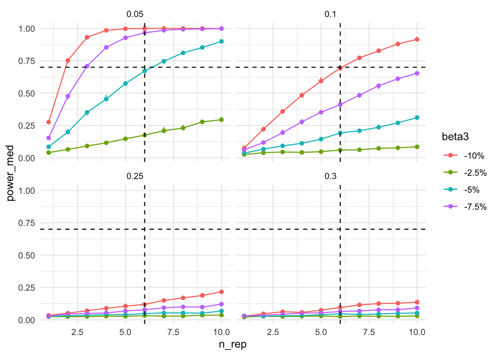

```r
# summarise the data for plotting
power_e2$beta3 <- paste0((exp(power_e2$beta3) - 1)*100, "%")

# summarise the data
power_e2_sum <-
  power_e2 |>
  dplyr::mutate(beta3 = as.character(beta3)) |>
  dplyr::group_by(sigma_residual, beta3, n_rep) |>
  dplyr::summarise(power_med = median(power),
                   quantile_low = quantile(power, 0.10),
                   quantile_high = quantile(power, 0.90))
# plot the data
ggplot(data = power_e2_sum,
       mapping = aes(x = n_rep, y = power_med, colour = beta3)) +
  geom_errorbar(mapping = aes(x = n_rep,
                              ymin = quantile_low, ymax = quantile_high,
                              colour = beta3),
                width = 0) +
  geom_point() +
  geom_line() +
  geom_vline(xintercept = 6, linetype = "dashed") +
  geom_hline(yintercept = 0.70, linetype = "dashed") +
  facet_wrap(~sigma_residual) +
  theme_minimal()
```

## Experiment 3:

In this experiment, we are interested in whether the competitive effect of invasives (I) on natives (L) increases with nitrogen (N) in the presence of microbes (M). This is a three-way interaction term. In this case, our hypothesis is that the three-way interaction term is negative because this would imply that the competitive effect of invasives on natives changes with nitrogen but only in the presence of microbes. Note that, in this experiment, we are manipulating the presence-absence of invasives and, therefore, the I term in the models is a zero-one term indicating the absence or presence of an invasive in the pot.

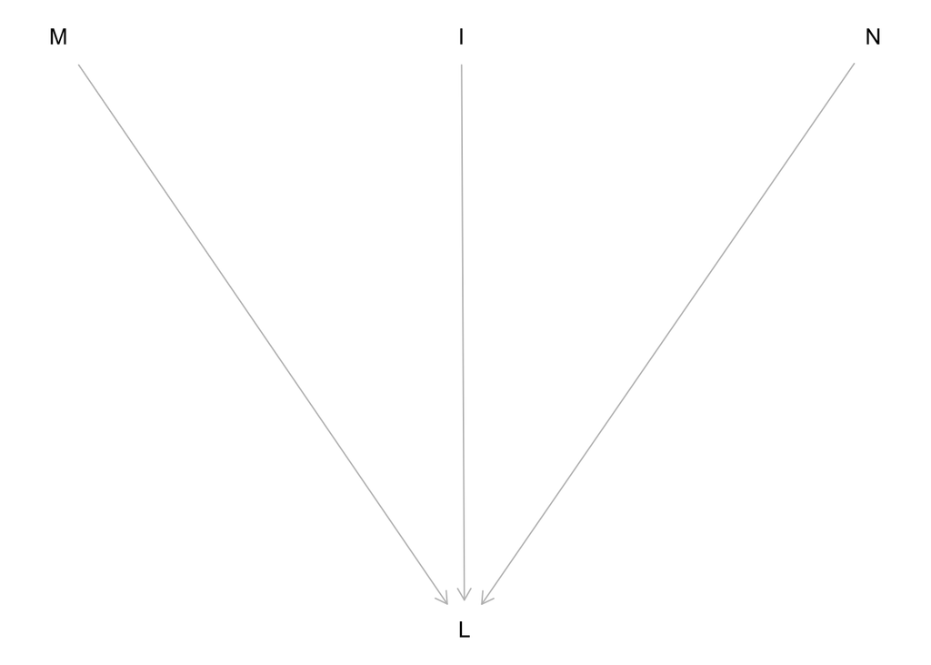

```r
dag3 <- dagitty::dagitty(x = 'dag {
bb="0,0,1,1"
I [exposure,pos="0.284,0.180"]
L [outcome,pos="0.285,0.300"]
M [pos="0.153,0.180"]
N [pos="0.418,0.180"]
I -> L
M -> L
N -> L
}
'
)
plot(dag3)
```

$$L_{i} = e^{\alpha + \beta_1\text{N}_{i} + \beta_2\text{M}_{i} + \beta_3\text{I}_{i} + \beta_4\text{N}_{i}\text{M}_{i} + \beta_5\text{I}_{i}\text{M}_{i} + \beta_6\text{I}_{i}\text{N}_{i} + \beta_7\text{N}_{i}\text{M}_{i}\text{I}_{i} + \epsilon_{i}} \\
\epsilon_{i} \sim Normal(0, \sigma_{residual})$$

```r
# set the number of replicates
n_rep <- 100

# nitrogen-levels
N_lev <- log(c(4, 8, 16, 32))

# soil microbe presence-absence
M_lev <- c(0, 1)

# invasive presence-absence
I_lev <- c(0, 1)

# create a grid of parameters
par_grid <- expand.grid(rep = seq_len(n_rep),
                        N = N_lev, M = M_lev, I = I_lev)

# extract the variables
N <- par_grid[["N"]]
M <- par_grid[["M"]]
I <- par_grid[["I"]]
```

Next, we set-up the model parameters.

```r
# set the model parameters

# residual standard deviation
sigma_residual <- 0.10

# alpha - mean plant biomass without microbes on the log-scale
alpha <- 1.5

# beta1 - expected change in plant biomass (log-scale) with one unit increase in N, without microbes, without invasives
beta1 <- 0.10

# beta2 - expected change in plant biomass (log-scale) with microbe addition, when N is zero and without invasives
beta2 <- -0.25

# beta3 - expected change in plant biomass (log-scale) with invasive addition, when N is zero and without microbes
beta3 <- -0.10

# beta4 -
beta4 <- -0.05

# beta5
beta5 <- 0

# beta6
beta6 <- 0

# beta7
beta7 <- -0.05
```

```r
# simulate the observed plant biomass
L <- (exp(alpha + (beta1 * N) + (beta2 * M) + (beta3 * I) + (beta4 * N * M) + (beta5 * I * M) + (beta6 * I * N) + (beta7 * N * M * I) + rnorm(n = length(N), 0, sigma_residual)))
```

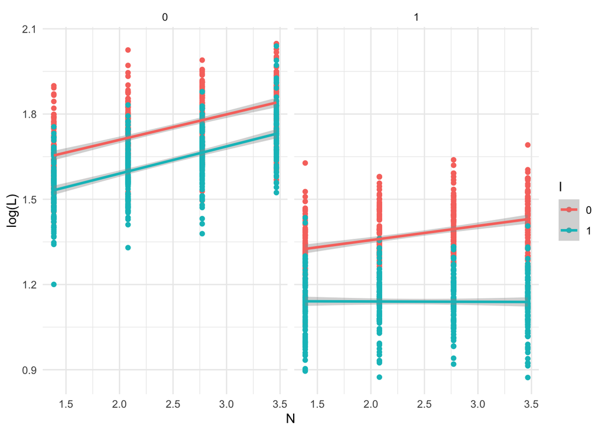

```r
# pull into a data.frame for plotting
dat_e3 <- dplyr::tibble(N = N, M = as.character(M), I = as.character(I), L)

ggplot(data = dat_e3,
       mapping = aes(x = N, y = log(L), colour = I)) +
  geom_point() +
  geom_smooth(method ="lm") +
  facet_wrap(~ M) +
  theme_minimal()
```

```r
# fit the model
lm_e3 <- lm(log(L) ~ N + M + I + N:M + I:M + I:N + M:I:N, data = dat_e3)
summary(lm_e3)
```

```
Call:
lm(formula = log(L) ~ N + M + I + N:M + I:M + I:N + M:I:N, data = dat_e3)

Residuals:
     Min       1Q   Median       3Q      Max
-0.33157 -0.06347 -0.00017  0.06693  0.30915

Coefficients:
             Estimate Std. Error t value Pr(>|t|)
(Intercept)  1.530144   0.016357  93.545  < 2e-16 ***
N            0.089524   0.006423  13.939  < 2e-16 ***
M1          -0.274455   0.023133 -11.864  < 2e-16 ***
I1          -0.130760   0.023133  -5.653 1.87e-08 ***
N:M1        -0.039258   0.009083  -4.322 1.64e-05 ***
M1:I1        0.017494   0.032714   0.535    0.593
N:I1         0.006037   0.009083   0.665    0.506
N:M1:I1     -0.057400   0.012845  -4.469 8.43e-06 ***
---
Signif. codes:  0 '***' 0.001 '**' 0.01 '*' 0.05 '.' 0.1 ' ' 1

Residual standard error: 0.09955 on 1592 degrees of freedom
Multiple R-squared:  0.8548,    Adjusted R-squared:  0.8542
F-statistic:  1339 on 7 and 1592 DF,  p-value: < 2.2e-16
```

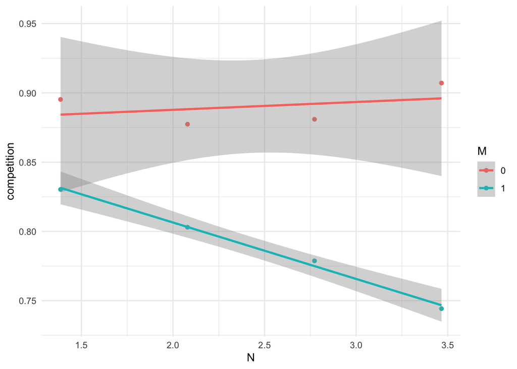

```r
# calculate competition by comparing natives with and without invasives
comp_sum <-
  dat_e3 |>
  dplyr::group_by(N, M, I) |>
  dplyr::summarise(mean_L = mean(L)) |>
  dplyr::ungroup() |>
  tidyr::pivot_wider(id_cols = c("N", "M"),
                     names_from = "I",
                     values_from = "mean_L")
names(comp_sum) <- c("N", "M", "without_I", "with_I")

# calculate competition
comp_sum$competition <- with(comp_sum, with_I/without_I)

# plot the data
ggplot(data = comp_sum,
       mapping = aes(x = N, y = competition, colour = M)) +
  geom_point() +
  geom_smooth(method = "lm") +
  theme_minimal()
```

Next, we will wrap these simulations into functions so that we can easily repeat this with different parameter values and, therefore, run the relevant power analyses.

```r
#' @param n_rep Integer. Number of replicates for each nitrogen-microbe combination.
#' @param sigma_residual Numeric. Residual standard deviation for log biomass.
#' @param N_lev Numeric vector. Log-transformed nitrogen levels.
#' @param M_lev Numeric vector. Soil microbe presence-absence (0 for absence, 1 for presence).
#' @param I_lev Numeric vector. Invasive presence-absence (0 for absence, 1 for presence).
#' @param alpha Numeric. Intercept representing the mean biomass without microbes on the natural scale.
#' @param beta1 Numeric. Expected change in mean biomass with increasing nitrogen without microbes, without invasives
#' @param beta2 Numeric. Effect of microbes on mean biomass when nitrogen level is zero and without invasives
#' @param beta3 Numeric. Additional change in the effect of nitrogen with microbes compared to without microbes
#' @param beta4 Numeric. Additional change in the effect of nitrogen with microbes compared to without microbes
#' @param beta5 Numeric. Additional change in the effect of nitrogen with microbes compared to without microbes
#' @param beta6 Numeric. Additional change in the effect of nitrogen with microbes compared to without microbes
#' @param beta7 Numeric. Additional change in the effect of nitrogen with microbes compared to without microbes

simulate_e3 <- function(
  n_rep = 10,
  sigma_residual = 0.15,
  N_lev = log(c(4, 8, 16, 32)),
  M_lev = c(0, 1),
  I_lev = c(0, 1),
  alpha = 4.5,
  beta1 = 0.2,
  beta2 = -0.12,
  beta3 = 0,
  beta4 = 0,
  beta5 = 0,
  beta6 = 0,
  beta7 = -0.05
) {

  # create a grid of parameters
  par_grid <- expand.grid(rep = seq_len(n_rep),
                          N = N_lev, M = M_lev, I = I_lev)

  # extract the variables
  N <- par_grid[["N"]]
  M <- par_grid[["M"]]
  I <- par_grid[["I"]]

  # simulate the expected log plant biomass
  L <- (exp(alpha + (beta1 * N) + (beta2 * M) + (beta3 * I) + (beta4 * N * M) + (beta5 * I * M) + (beta6 * I * N) + (beta7 * N * M * I)) + rnorm(n = length(N), 0, sigma_residual))

  # return the simulated data as a data frame
  dplyr::tibble("N" = N, "M" = M, "I" = I, "L" = L)

}

#' @param n_sim - number of simulations to run of the experiment
#' @param beta7_h0 - beta3 under the null hypothesis
#' @param beta7_ha - beta3 under the alternative hypothesis

e3_power <- function(
    n_sim = 10,
    alpha_rej = 0.05,
    n_rep = 10,
    sigma_residual = 0.15,
    N_lev = log(c(4, 8, 16, 32)),
    M_lev = c(0, 1),
    I_lev = c(0, 1),
    alpha = 4.5,
    beta1 = 0.2,
    beta2 = -0.12,
    beta3 = 0,
    beta4 = 0,
    beta5 = 0,
    beta6 = 0,
    beta7_h0 = 0,
    beta7_ha = -0.05) {

    # initialize vectors to store Type I and Type II errors
    type_I_errors <- vector(length = n_sim)
    type_II_errors <- vector(length = n_sim)

    # simulate under H0 (Null Hypothesis)
    for (i in seq_len(n_sim)) {

      # generate data under H0
      data_h0 <-
        simulate_e3(
          n_rep = n_rep,
          sigma_residual = sigma_residual,
          N_lev = N_lev,
          M_lev = M_lev,
          alpha = alpha,
          beta1 = beta1,
          beta2 = beta2,
          beta3 = beta3,
          beta4 = beta4,
          beta5 = beta5,
          beta6 = beta6,
          beta7 = beta7_h0)

      # fit the model under H0
      model_h0 <- lm(log(L) ~ N + M + I + N:M + I:M + I:N + M:I:N, data_h0)

      # extract the relevant p-value
      p_value_h0 <- coef(summary(model_h0))["N:M:I", "Pr(>|t|)"]

      # collect Type I error
      type_I_errors[i] <- as.numeric(p_value_h0 < alpha_rej)

    }

    # simulate under HA (Alternative Hypothesis)
    for (i in seq_len(n_sim)) {

      # generate data under HA
      data_ha <-
        simulate_e3(
          n_rep = n_rep,
          sigma_residual = sigma_residual,
          N_lev = N_lev,
          M_lev = M_lev,
          alpha = alpha,
          beta1 = beta1,
          beta2 = beta2,
          beta3 = beta3,
          beta4 = beta4,
          beta5 = beta5,
          beta6 = beta6,
          beta7 = beta7_ha)

      # fit the model under H0
      model_ha <-  lm(log(L) ~ N + M + I + N:M + I:M + I:N + M:I:N, data_ha)

      # extract the relevant p-value
      p_value_ha <- coef(summary(model_ha))["N:M:I", "Pr(>|t|)"]

      # collect Type I error
      type_II_errors[i] <- as.numeric(p_value_ha >= alpha_rej)

    }

    # calculate metrics
    type_I_error_rate <- sum(type_I_errors, na.rm = TRUE) / length(na.omit(type_I_errors))
    type_II_error_rate <- sum(type_II_errors, na.rm = TRUE) / length(na.omit(type_II_errors))
    power <- 1 - type_II_error_rate

    # return results
    list(
      type_I_error_rate = type_I_error_rate,
      type_II_error_rate = type_II_error_rate,
      power = power
      )

  }
```

Let’s test this power function:

```r
# simulate an experiment
e3_power(
  n_sim = 1000,
  alpha_rej = 0.05,
  n_rep = 10,
  sigma_residual = 0.15,
  N_lev = log(c(4, 8, 16, 32)),
  M_lev = c(0, 1),
  I_lev = c(0, 1),
  alpha = 4.5,
  beta1 = 0.2,
  beta2 = -0.12,
  beta3 = 0,
  beta4 = 0,
  beta5 = 0,
  beta6 = 0,
  beta7_h0 = 0,
  beta7_ha = -0.05)
```

```
$type_I_error_rate
[1] 0.052

$type_II_error_rate
[1] 0

$power
[1] 1
```

Our hypothesis is based on the $\beta_7$ parameter being negative (i.e. the competitive effect of invasives on natives increases with nitrogen in the presence of microbes). Therefore, we estimated power based on four hypothesized values:

- $\beta_7$ = 2.5%, 5%, 7.5% or 10% decrease in biomass with a simultaneous increase of N by 1 unit, going from no microbes to microbes and going from no invasive to invasive.

```r
# set-up the parameters

# convert percentage to parameter for the log-scale
par_target <- function(target) log(1 + target)

# number of replicates
n_rep <- seq(1, 10, 1)

# alpha - mean plant biomass without microbes on the log-scale
alpha <- 1.5

# beta1 - expected change in mean plant biomass with N without microbes on the log-scale
beta1 <- sapply(c(0.5, 1.5, 3), par_target)

# beta2 - expected change in mean plant biomass with and without microbes when N is minimum
beta2 <- sapply(c(-0.05, -0.15, -0.25), par_target)

# beta3 - additional change in the effect of N on mean plant biomass with microbes compared to without microbes
beta3 <- sapply(c(-0.10, -0.075, -0.05, -0.025), par_target)

# beta4 -
beta4 <- sapply(0, par_target)

# beta5 -
beta5 <- sapply(0, par_target)

# beta6 -
beta6 <- sapply(0, par_target)

# beta7 -
beta7 <- sapply(c(-0.10, -0.075, -0.05, -0.025), par_target)

# sigma residual
sigma_residual <- c(0.05, 0.10, 0.25, 0.3)

# pull the parameter list into a data.frame
params <- expand.grid( n_rep = n_rep,
                      alpha = alpha, beta1 = beta1,
                      beta2 = beta2, beta3 = beta3,
                      beta4 = beta4, beta5 = beta5,
                      beta6 = beta6, beta7 = beta7,
                      sigma_residual = sigma_residual)

# convert to a tibble
params <- dplyr::as_tibble(params)

# print the first few rows
head(params)
```

```
# A tibble: 6 × 10
  n_rep alpha beta1   beta2  beta3 beta4 beta5 beta6  beta7 sigma_residual
  <dbl> <dbl> <dbl>   <dbl>  <dbl> <dbl> <dbl> <dbl>  <dbl>          <dbl>
1     1   1.5 0.405 -0.0513 -0.105     0     0     0 -0.105           0.05
2     2   1.5 0.405 -0.0513 -0.105     0     0     0 -0.105           0.05
3     3   1.5 0.405 -0.0513 -0.105     0     0     0 -0.105           0.05
4     4   1.5 0.405 -0.0513 -0.105     0     0     0 -0.105           0.05
5     5   1.5 0.405 -0.0513 -0.105     0     0     0 -0.105           0.05
6     6   1.5 0.405 -0.0513 -0.105     0     0     0 -0.105           0.05
```

Run the power analysis.

```r
# loop over each of these parameter combinations
power_list <- vector("list", length = nrow(params))
for (i in seq_along(power_list)) {

  # get the input parameters
  input_pars <- params[i, ]

  # run the simulation
  power_sim_data <-
    e3_power(
      n_sim = 1000,
      alpha_rej = 0.025,
      n_rep = input_pars$n_rep,
      sigma_residual = input_pars$sigma_residual,
      N_lev = log(c(4, 8, 16, 32)),
      M_lev = c(0, 1),
      I_lev = c(0, 1),
      alpha = input_pars$alpha,
      beta1 = input_pars$beta1,
      beta2 = input_pars$beta2,
      beta3 = input_pars$beta3,
      beta4 = input_pars$beta4,
      beta5 = input_pars$beta5,
      beta6 = input_pars$beta6,
      beta7_h0 = 0,
      beta7_ha = input_pars$beta7)

  # add the type I error, type II error and power to a list
  power_list[[i]] <-
    dplyr::tibble(run = i,
                  type_1_error = power_sim_data$type_I_error_rate,
                  type_2_error = power_sim_data$type_II_error_rate,
                  power = power_sim_data$power)

}

# bind into a data.frame
power_data <- dplyr::bind_rows(power_list)
head(power_data)
```

```
# A tibble: 6 × 4
    run type_1_error type_2_error power
  <int>        <dbl>        <dbl> <dbl>
1     1        0.031            0     1
2     2        0.032            0     1
3     3        0.037            0     1
4     4        0.031            0     1
5     5        0.033            0     1
6     6        0.032            0     1
```

```r
# bind to the parameter data
power_e3 <- dplyr::bind_cols(params, power_data)

# print the first few rows
head(power_e3)
```

```
# A tibble: 6 × 14
  n_rep alpha beta1   beta2  beta3 beta4 beta5 beta6  beta7 sigma_residual   run
  <dbl> <dbl> <dbl>   <dbl>  <dbl> <dbl> <dbl> <dbl>  <dbl>          <dbl> <int>
1     1   1.5 0.405 -0.0513 -0.105     0     0     0 -0.105           0.05     1
2     2   1.5 0.405 -0.0513 -0.105     0     0     0 -0.105           0.05     2
3     3   1.5 0.405 -0.0513 -0.105     0     0     0 -0.105           0.05     3
4     4   1.5 0.405 -0.0513 -0.105     0     0     0 -0.105           0.05     4
5     5   1.5 0.405 -0.0513 -0.105     0     0     0 -0.105           0.05     5
6     6   1.5 0.405 -0.0513 -0.105     0     0     0 -0.105           0.05     6
# ℹ 3 more variables: type_1_error <dbl>, type_2_error <dbl>, power <dbl>
```

Visualise the power analysis results.

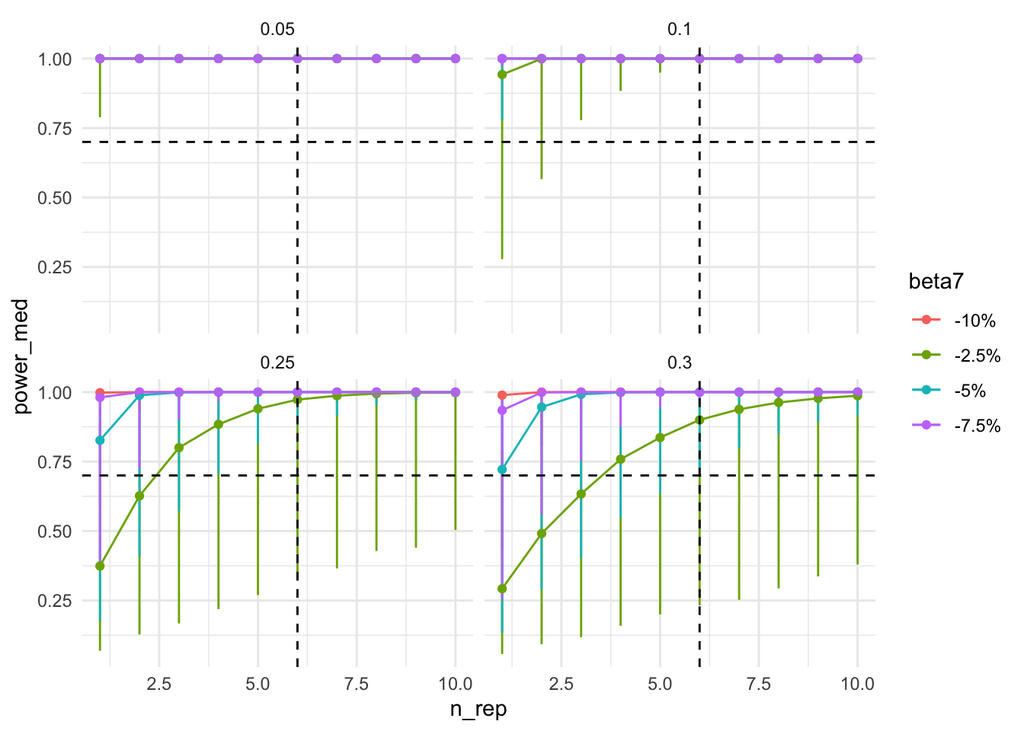

```r
# summarise the data for plotting
power_e3$beta7 <- paste0((exp(power_e3$beta7) - 1)*100, "%")

# summarise the data
power_e3_sum <-
  power_e3 |>
  dplyr::mutate(beta7 = as.character(beta7)) |>
  dplyr::group_by(sigma_residual, beta7, n_rep) |>
  dplyr::summarise(power_med = median(power),
                   quantile_low = quantile(power, 0.10),
                   quantile_high = quantile(power, 0.90))
# plot the data
ggplot(data = power_e3_sum,
       mapping = aes(x = n_rep, y = power_med, colour = beta7)) +
  geom_errorbar(mapping = aes(x = n_rep,
                              ymin = quantile_low, ymax = quantile_high,
                              colour = beta7),
                width = 0) +
  geom_point() +
  geom_line() +
  geom_vline(xintercept = 6, linetype = "dashed") +
  geom_hline(yintercept = 0.70, linetype = "dashed") +
  facet_wrap(~sigma_residual) +
  theme_minimal()
```